# Final Exam AMA-DS, January 2024. Practice

Lena Ebner

# 1 Algerian forest fires

The dataset firesAlg_tr (contained in firesAlg.Rdata) includes 183 instances that regroup a data of two regions of Algeria, namely the Bejaia region located in the northeast of Algeria and the Sidi Bel-abbes region located in the northwest of Algeria. Each instance corresponds to a different day in one of the two regions.

The dataset includes 10 explanatory attributes and 2 output attributes: 1. temp : temperature noon (temperature max) in Celsius degrees: 22 to 42 2. RH : Relative Humidity in %: 21 to 89 3. wind :Wind speed in km/h: 6 to 29 4. rain: total day in mm: 0 to 16.8 FWI Components 5. Fine Fuel Moisture Code (FFMC) index from the Fire Weather Index (FWI) system: 28.6 to 96 6. Duff Moisture Code (DMC) index from the FWI system: 0.7 to 65.9 7. Drought Code (DC) index from the FWI system: 6.9 to 220.4 8. Initial Spread Index (ISI) index from the FWI system: 0 to 19 9. Buildup Index (BUI) index from the FWI system: 1.1 to 68 10. Fire Weather Index (FWI) Index: 0 to 31.1 11. fire: (output) 0 for “not Fire”, 1 for “Fire” 12. region: (output) 0 for Bejaia, 1 for Sidi Bel-abbes The dataset firesAlg_test_blinded (also contained in firesAlg.Rdata) has similar structure as firesAlg_tr but it does not contain the output variables. There are 61 instances in firesAlg_test_blinded

```r
load("firesAlg.Rdata")
ls()
```

```
## [1] "firesAlg_test_blind" "firesAlg_tr"
```

```r
data <- firesAlg_tr
head(data)
```

```
##     temp RH wind rain FFMC  DMC    DC  ISI  BUI  FWI  fire region
## 104   29 88   13  0.0 71.0  2.6  16.6  1.2  3.7  0.5 FALSE      0
## 210   36 54   14  0.0 91.0 65.9 177.3 10.0 68.0 26.1  TRUE      1
## 100   30 73   17  0.9 62.0  2.6   8.4  1.1  3.0  0.4 FALSE      0
## 51    33 70   17  0.0 85.4 18.5  71.5  5.2 22.4  8.8  TRUE      0
## 214   30 59   19  0.0 89.1 27.8 168.2  9.8 39.3 19.4  TRUE      1
## 144   33 46   14  1.1 78.3  8.1   8.3  1.9  7.7  1.2 FALSE      1
```

## 1.1 Second part

### 1.1.1 1. Generalized additive model for a binary variable

#### 1.1.1.1 1.1

Use firesAlg_tr to fit a generalized additive model with response the variable region and explanatory variables chosen among the first 10 columns of firesAlg_tr. • Justify the steps you do in the model choice process. • Indicate clearly which is your finally chosen model.

```r
library(mgcv)
```

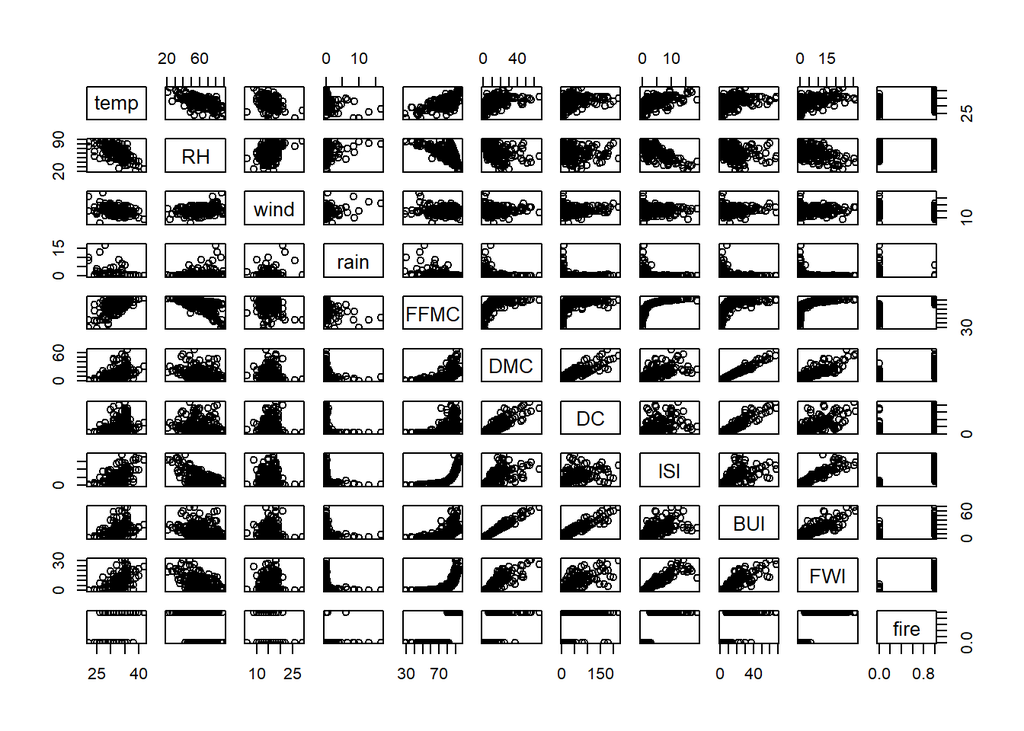

```r
plot(data[,1:11])
```

**Model 1.0**:

First we fit an additive model with all the variables smoothed

```r
gam1.0 <- gam(region ~ s(temp) +s(RH) + s(wind)+ s(rain) + s(FFMC) + s(DMC) + s(DC) + s(ISI) + s(BUI) + s(FWI), data=data)
summary(gam1.0)
```

```
##
## Family: gaussian
## Link function: identity
##
## Formula:
## region ~ s(temp) + s(RH) + s(wind) + s(rain) + s(FFMC) + s(DMC) +
##     s(DC) + s(ISI) + s(BUI) + s(FWI)
##
## Parametric coefficients:
##             Estimate Std. Error t value Pr(>|t|)
## (Intercept)  0.50273    0.02756   18.24   <2e-16 ***
## ---
## Signif. codes:  0 '***' 0.001 '**' 0.01 '*' 0.05 '.' 0.1 ' ' 1
##
## Approximate significance of smooth terms:
##           edf Ref.df     F  p-value
## s(temp) 1.000  1.000 0.112 0.738319
## s(RH)   4.376  5.385 2.970 0.011465 *
## s(wind) 3.916  4.822 0.917 0.516950
## s(rain) 4.900  5.895 1.962 0.073110 .
## s(FFMC) 2.382  3.022 0.791 0.512289
## s(DMC)  2.603  3.285 6.467 0.000265 ***
## s(DC)   3.492  4.356 2.602 0.045214 *
## s(ISI)  1.000  1.000 0.000 0.986672
## s(BUI)  1.452  1.658 2.745 0.156899
## s(FWI)  1.000  1.000 1.121 0.291241
## ---
## Signif. codes:  0 '***' 0.001 '**' 0.01 '*' 0.05 '.' 0.1 ' ' 1
##
## R-sq.(adj) =  0.447   Deviance explained = 52.6%
## GCV = 0.16322  Scale est. = 0.13903   n = 183
```

Only smoothed variables DMC, DC, RH are considered as significant. Temp, ISI, FWI have a smoothing term edf of one so we will remove the smoothing term of them in the next model.

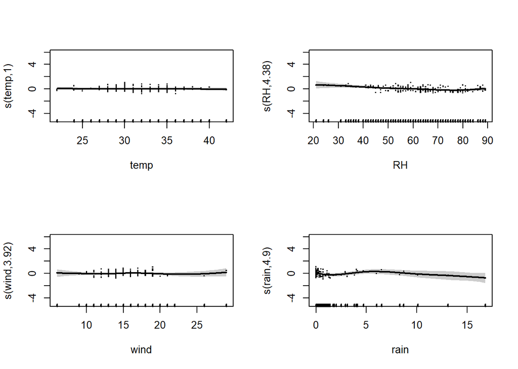

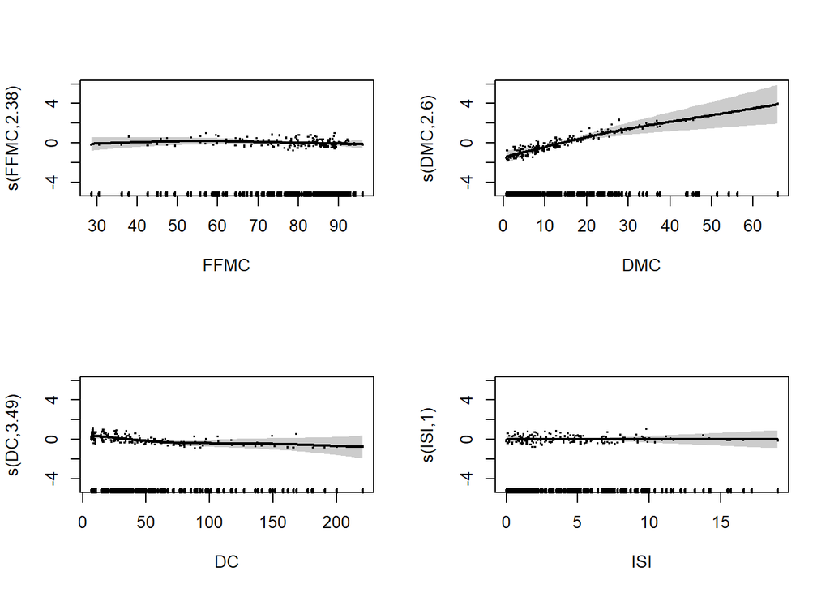

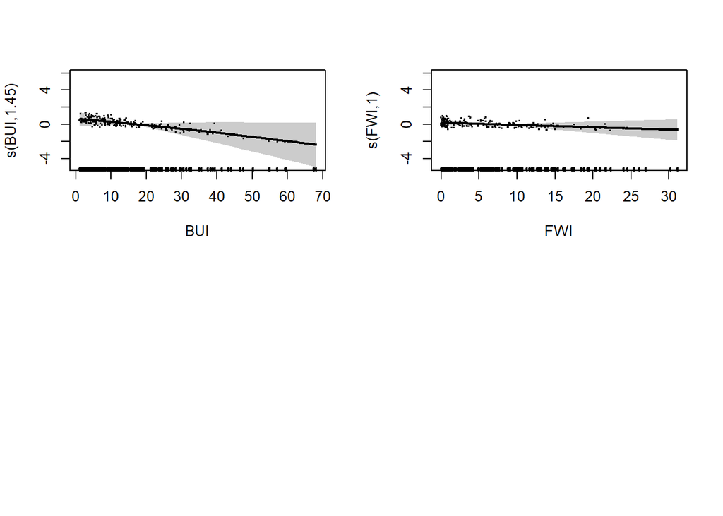

```r
par(mfrow=c(4,2))
plot(gam1.0,pages=3, residuals=TRUE, shade=TRUE, cex=2, lwd=2)
```

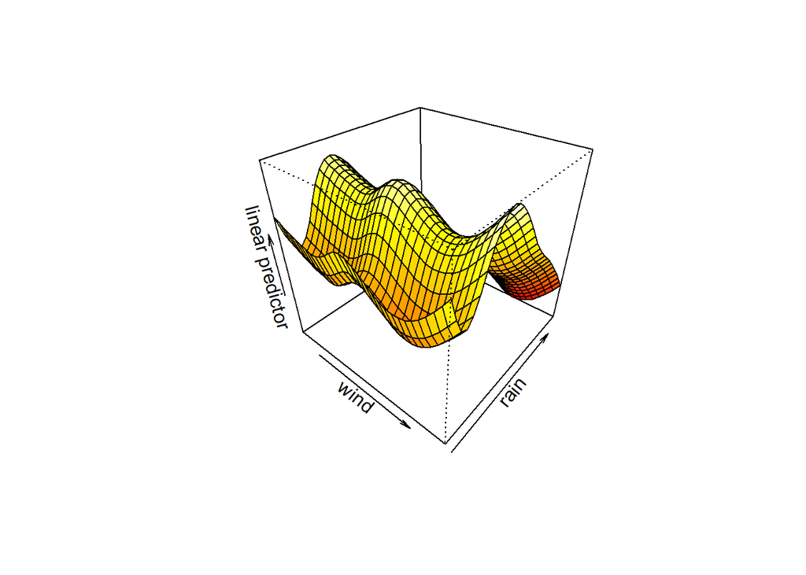

```r
vis.gam(gam1.0,view=c("wind","rain"),
        theta = 40, phi = 35, r = sqrt(4), d = 1,)
```

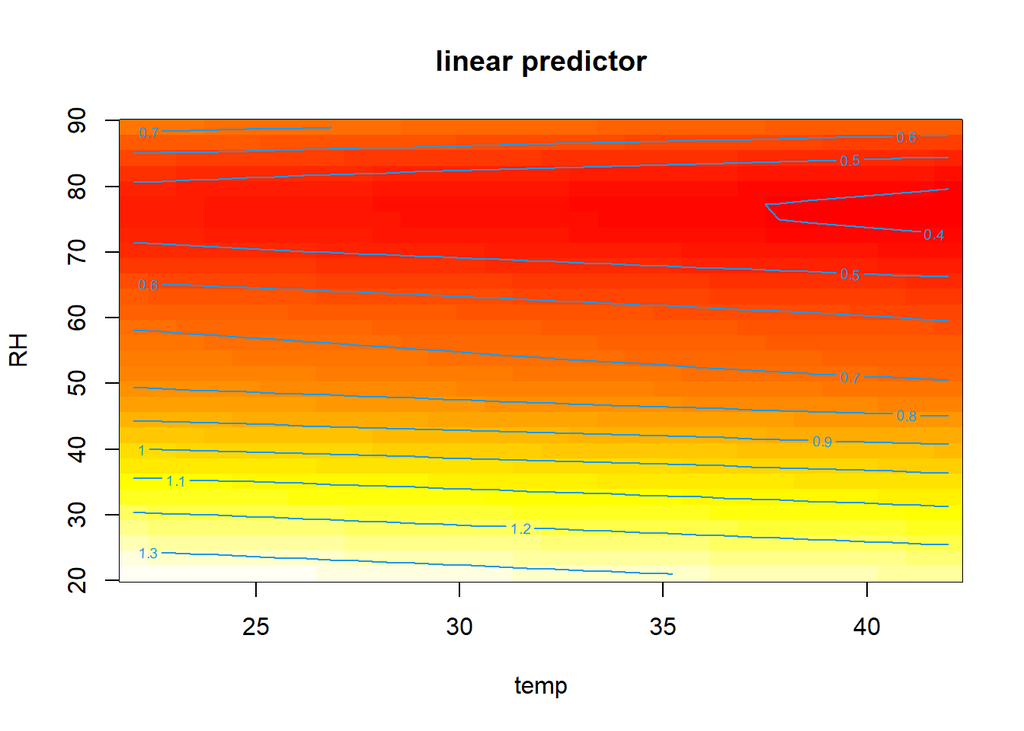

```r
vis.gam(gam1.0, view=c("temp","RH"), plot.type = "contour")
```

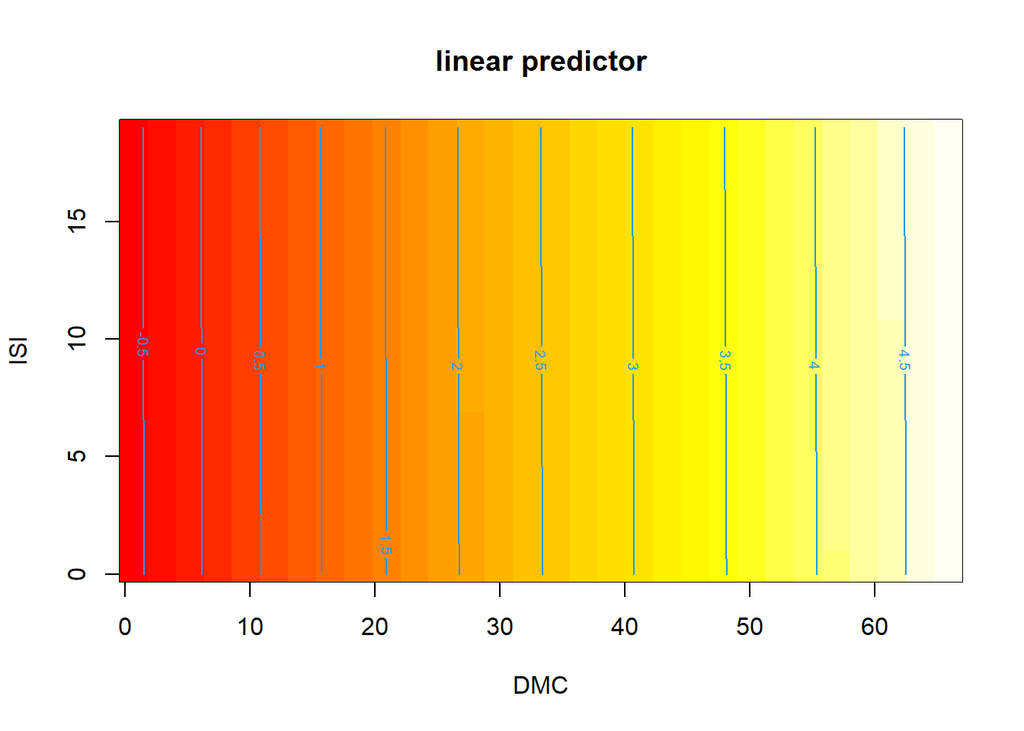

```r
vis.gam(gam1.0, view=c("DMC","ISI"), plot.type = "contour")
```

**Model 2**:

```r
gam2.0 <- gam(region ~ temp + s(RH) + s(wind)+ s(rain) + s(FFMC) + s(DMC) + s(DC) + ISI + s(BUI) + FWI, data=data)
summary(gam2.0)
```

```
##
## Family: gaussian
## Link function: identity
##
## Formula:
## region ~ temp + s(RH) + s(wind) + s(rain) + s(FFMC) + s(DMC) +
##     s(DC) + ISI + s(BUI) + FWI
##
## Parametric coefficients:
##               Estimate Std. Error t value Pr(>|t|)
## (Intercept)  0.8270136  0.4175156   1.981   0.0494 *
## temp        -0.0041997  0.0125483  -0.335   0.7383
## ISI          0.0005391  0.0322132   0.017   0.9867
## FWI         -0.0272613  0.0257426  -1.059   0.2912
## ---
## Signif. codes:  0 '***' 0.001 '**' 0.01 '*' 0.05 '.' 0.1 ' ' 1
##
## Approximate significance of smooth terms:
##           edf Ref.df     F  p-value
## s(RH)   4.376  5.385 2.970 0.011465 *
## s(wind) 3.916  4.822 0.917 0.516951
## s(rain) 4.900  5.895 1.962 0.073109 .
## s(FFMC) 2.382  3.022 0.791 0.512282
## s(DMC)  2.602  3.285 6.467 0.000265 ***
## s(DC)   3.492  4.356 2.602 0.045216 *
## s(BUI)  1.452  1.658 2.745 0.156911
## ---
## Signif. codes:  0 '***' 0.001 '**' 0.01 '*' 0.05 '.' 0.1 ' ' 1
##
## R-sq.(adj) =  0.447   Deviance explained = 52.6%
## GCV = 0.16322  Scale est. = 0.13903   n = 183
```

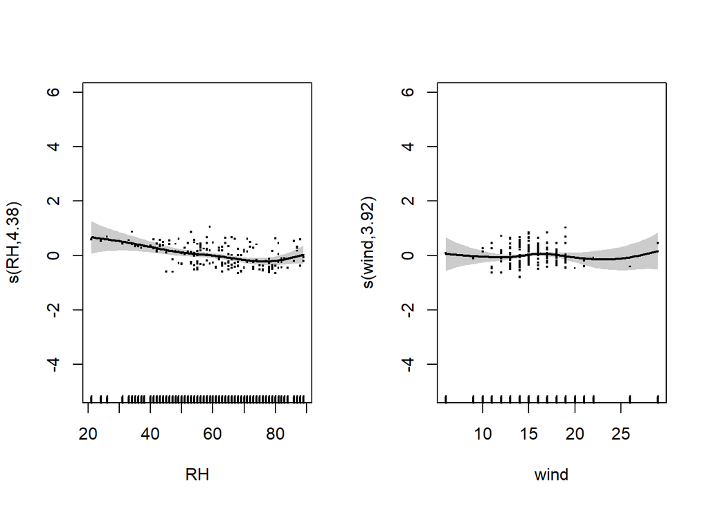

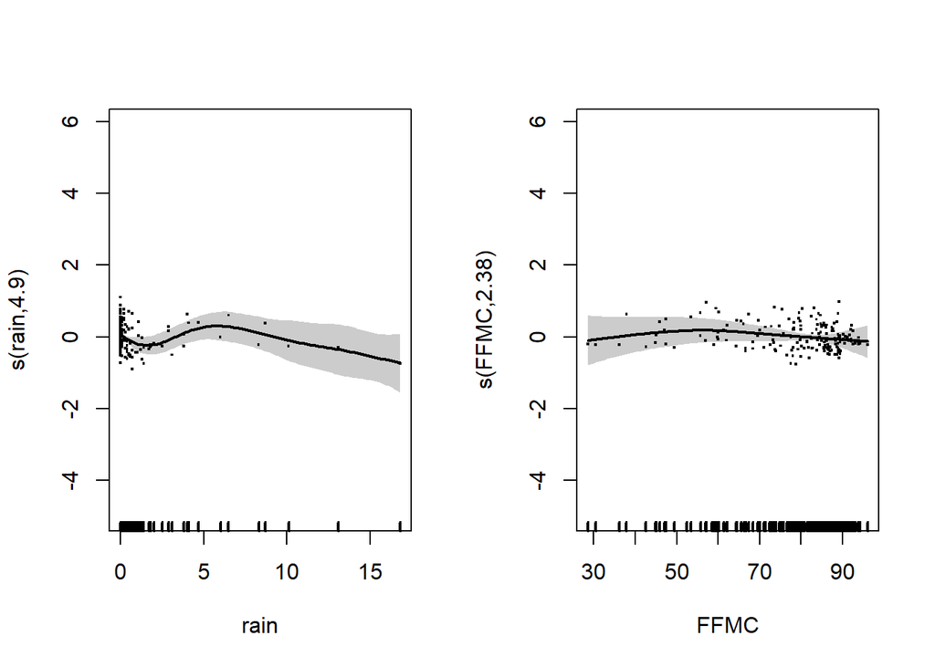

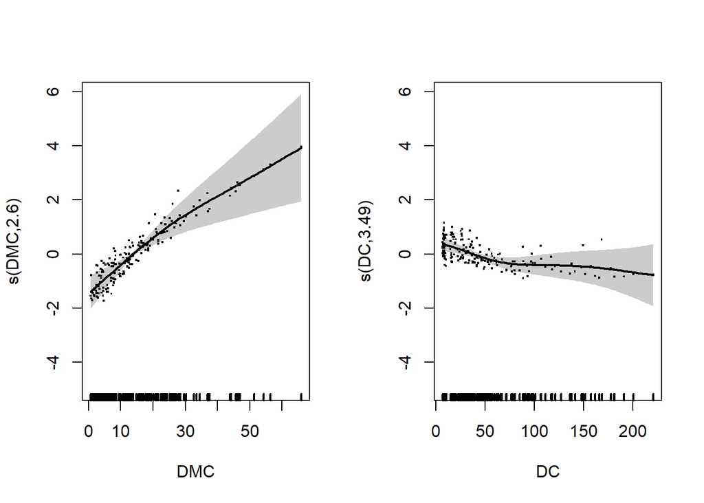

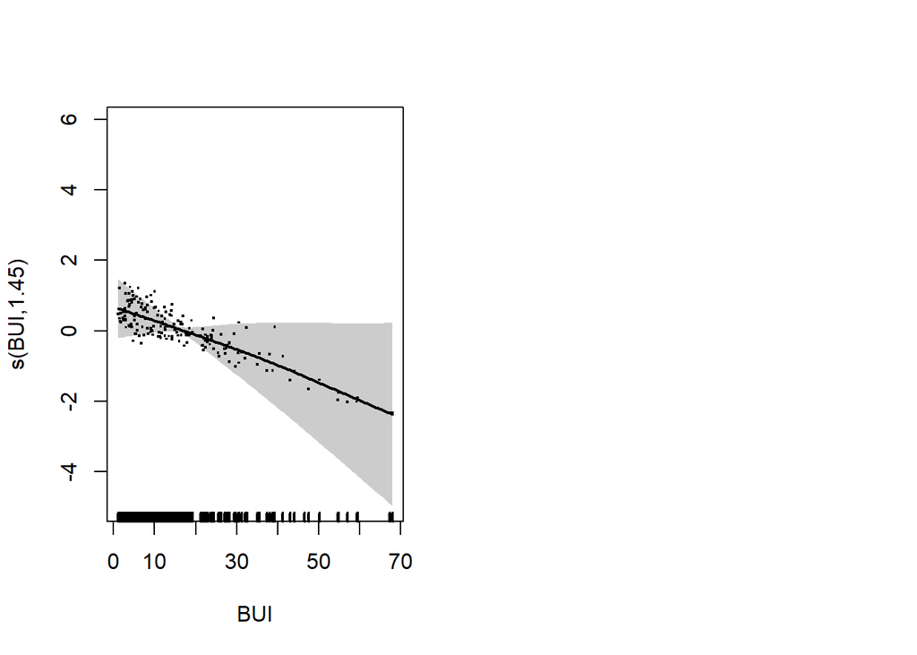

```r
plot(gam2.0,pages=4, residuals=TRUE, shade=TRUE, cex=2, lwd=2)
```

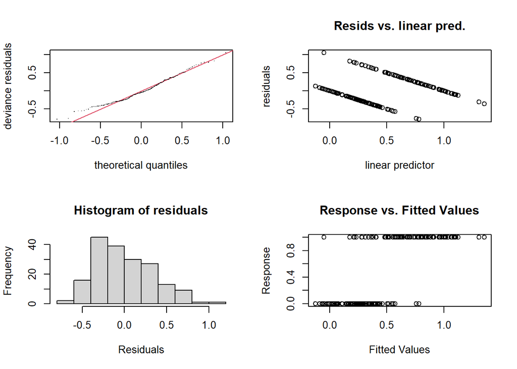

```
##
## Method: GCV   Optimizer: magic
## Smoothing parameter selection converged after 10 iterations.
## The RMS GCV score gradient at convergence was 1.720103e-06 .
## The Hessian was positive definite.
## Model rank =  67 / 67
##
## Basis dimension (k) checking results. Low p-value (k-index<1) may
## indicate that k is too low, especially if edf is close to k'.
##
##           k'  edf k-index p-value
## s(RH)   9.00 4.38    1.08   0.805
## s(wind) 9.00 3.92    0.99   0.400
## s(rain) 9.00 4.90    0.89   0.045 *
## s(FFMC) 9.00 2.38    1.09   0.895
## s(DMC)  9.00 2.60    1.02   0.590
## s(DC)   9.00 3.49    0.95   0.255
## s(BUI)  9.00 1.45    1.14   0.965
## ---
## Signif. codes:  0 '***' 0.001 '**' 0.01 '*' 0.05 '.' 0.1 ' ' 1
```

```r
gam.check(gam2.0)
```

But this does not help us in getting a better variance explained in the model. Sow we trz to add more complexity bz adding some tensor products beween interaction variables.

```r
gam3.0 <- gam(region ~ temp + te(wind, rain) + s(RH) + te(FFMC, FWI) + s(DMC) + s(DC) + ISI + s(BUI) + FWI+ te(DC,BUI) + te(DC,ISI), data=data)
summary(gam3.0)
```

```
##
## Family: gaussian
## Link function: identity
##
## Formula:
## region ~ temp + te(wind, rain) + s(RH) + te(FFMC, FWI) + s(DMC) +
##     s(DC) + ISI + s(BUI) + FWI + te(DC, BUI) + te(DC, ISI)
##
## Parametric coefficients:
##              Estimate Std. Error t value Pr(>|t|)
## (Intercept)  2.412695   1.030592   2.341   0.0205 *
## temp        -0.000106   0.012286  -0.009   0.9931
## ISI          0.028933   0.038230   0.757   0.4503
## FWI         -0.290829   0.144619  -2.011   0.0461 *
## ---
## Signif. codes:  0 '***' 0.001 '**' 0.01 '*' 0.05 '.' 0.1 ' ' 1
##
## Approximate significance of smooth terms:
##                 edf Ref.df     F  p-value
## te(wind,rain) 6.893  7.599 3.960 0.000431 ***
## s(RH)         1.795  2.291 4.272 0.013641 *
## te(FFMC,FWI)  6.626  7.788 1.509 0.160791
## s(DMC)        1.497  1.869 5.588 0.010021 *
## s(DC)         1.000  1.000 6.984 0.009084 **
## s(BUI)        1.000  1.000 7.728 0.006125 **
## te(DC,BUI)    4.886  5.326 3.219 0.006498 **
## te(DC,ISI)    3.730 20.000 0.446 0.017765 *
## ---
## Signif. codes:  0 '***' 0.001 '**' 0.01 '*' 0.05 '.' 0.1 ' ' 1
##
## Rank: 129/130
## R-sq.(adj) =  0.491   Deviance explained = 57.6%
## GCV = 0.15449  Scale est. = 0.12797   n = 183
```

Annova Test for comparing models:

```r
anova(gam1.0, gam2.0, test="F")
```

```
## Analysis of Deviance Table
##
## Model 1: region ~ s(temp) + s(RH) + s(wind) + s(rain) + s(FFMC) + s(DMC) +
##     s(DC) + s(ISI) + s(BUI) + s(FWI)
## Model 2: region ~ temp + s(RH) + s(wind) + s(rain) + s(FFMC) + s(DMC) +
##     s(DC) + ISI + s(BUI) + FWI
##   Resid. Df Resid. Dev         Df   Deviance      F    Pr(>F)
## 1    150.58     21.672
## 2    150.58     21.672 0.00017869 3.8351e-05 1.5437 0.0007429 ***
## ---
## Signif. codes:  0 '***' 0.001 '**' 0.01 '*' 0.05 '.' 0.1 ' ' 1
```

```r
anova(gam1.0, gam3.0, test="F")
```

```
## Analysis of Deviance Table
##
## Model 1: region ~ s(temp) + s(RH) + s(wind) + s(rain) + s(FFMC) + s(DMC) +
##     s(DC) + s(ISI) + s(BUI) + s(FWI)
## Model 2: region ~ temp + te(wind, rain) + s(RH) + te(FFMC, FWI) + s(DMC) +
##     s(DC) + ISI + s(BUI) + FWI + te(DC, BUI) + te(DC, ISI)
##   Resid. Df Resid. Dev     Df Deviance      F    Pr(>F)
## 1    150.58     21.672
## 2    147.40     19.399 3.1799   2.2721 5.5834 0.0009306 ***
## ---
## Signif. codes:  0 '***' 0.001 '**' 0.01 '*' 0.05 '.' 0.1 ' ' 1
```

```r
anova(gam2.0, gam3.0, test="F")
```

```
## Analysis of Deviance Table
##
## Model 1: region ~ temp + s(RH) + s(wind) + s(rain) + s(FFMC) + s(DMC) +
##     s(DC) + ISI + s(BUI) + FWI
## Model 2: region ~ temp + te(wind, rain) + s(RH) + te(FFMC, FWI) + s(DMC) +
##     s(DC) + ISI + s(BUI) + FWI + te(DC, BUI) + te(DC, ISI)
##   Resid. Df Resid. Dev     Df Deviance      F    Pr(>F)
## 1    150.58     21.672
## 2    147.40     19.399 3.1797   2.2721 5.5836 0.0009305 ***
## ---
## Signif. codes:  0 '***' 0.001 '**' 0.01 '*' 0.05 '.' 0.1 ' ' 1
```

```r
anova(gam1.0, gam3.0, gam3.0, test="F")
```

```
## Analysis of Deviance Table
##
## Model 1: region ~ s(temp) + s(RH) + s(wind) + s(rain) + s(FFMC) + s(DMC) +
##     s(DC) + s(ISI) + s(BUI) + s(FWI)
## Model 2: region ~ temp + te(wind, rain) + s(RH) + te(FFMC, FWI) + s(DMC) +
##     s(DC) + ISI + s(BUI) + FWI + te(DC, BUI) + te(DC, ISI)
## Model 3: region ~ temp + te(wind, rain) + s(RH) + te(FFMC, FWI) + s(DMC) +
##     s(DC) + ISI + s(BUI) + FWI + te(DC, BUI) + te(DC, ISI)
##   Resid. Df Resid. Dev     Df Deviance      F    Pr(>F)
## 1    150.58     21.672
## 2    147.40     19.399 3.1799   2.2721 5.5834 0.0009306 ***
## 3    147.40     19.399 0.0000   0.0000
## ---
## Signif. codes:  0 '***' 0.001 '**' 0.01 '*' 0.05 '.' 0.1 ' ' 1
```

Based on the tests so far the best model is model3.0. But still this model is not able to explain more than 57% deviance.

#### 1.1.1.2 1.2

To evaluate the performance of your chosen model, I will take use the following quantity: C = Gtest − max{0, Gtr − Gtest},1 where Gtr is the proportion of good classified instances in the training sample, and Gtest is the proportion of good classified instances in the blinded test sample (I will compute this quantity later, when grading your exam). The quantity C will be large when both Gtr and Gtest are large and they are similar to each other. In an overfitted model Gtr would be much larger that Gtest and then C would not be so large. (Info: C is equal to 0.82 for the generalized linear model including all 10 explanatory variables. I’ve been able to fit a model for which C = 0.88.) Your grade at this item will be …

## 1.2 3

Consider the dataset obtained by joining 6 of the 10 columns that are common in firesAlg_tr and firesAlg_test_blinded:

```r
cols<- c(1,2,3,7,9,10)
firesAlg_6 <- rbind(firesAlg_tr[,cols],firesAlg_test_blind[,cols])
```

```r
library(ranger)
library(randomForest)
library(caret)
library(vip)
library(DALEX)
library(lime)
library(iml)
library(localModel)
# library(fastshap) # Attention! It re-define "explain" from DALEX
if (require(ghostvar)){library(ghostvar)}
library(mgcv)
library(gridExtra)
```

1. Compute the Variable Importance by the reduction of the impurity at the splits defined by each variable. (Hint: Use set.seed(1234) before calling the function ranger). Plot the results and comment on them.

```r
model_rf_imp <- ranger(
  FWI ~ .,
  data = firesAlg_6,
  importance='impurity' # default = none, no importances will be computed
)
print(model_rf_imp)
```

```
## Ranger result
##
## Call:
##  ranger(FWI ~ ., data = firesAlg_6, importance = "impurity")
##
## Type:                             Regression
## Number of trees:                  500
## Sample size:                      244
## Number of independent variables:  5
## Mtry:                             2
## Target node size:                 5
## Variable importance mode:         impurity
## Splitrule:                        variance
## OOB prediction error (MSE):       8.877333
## R squared (OOB):                  0.8391223
```

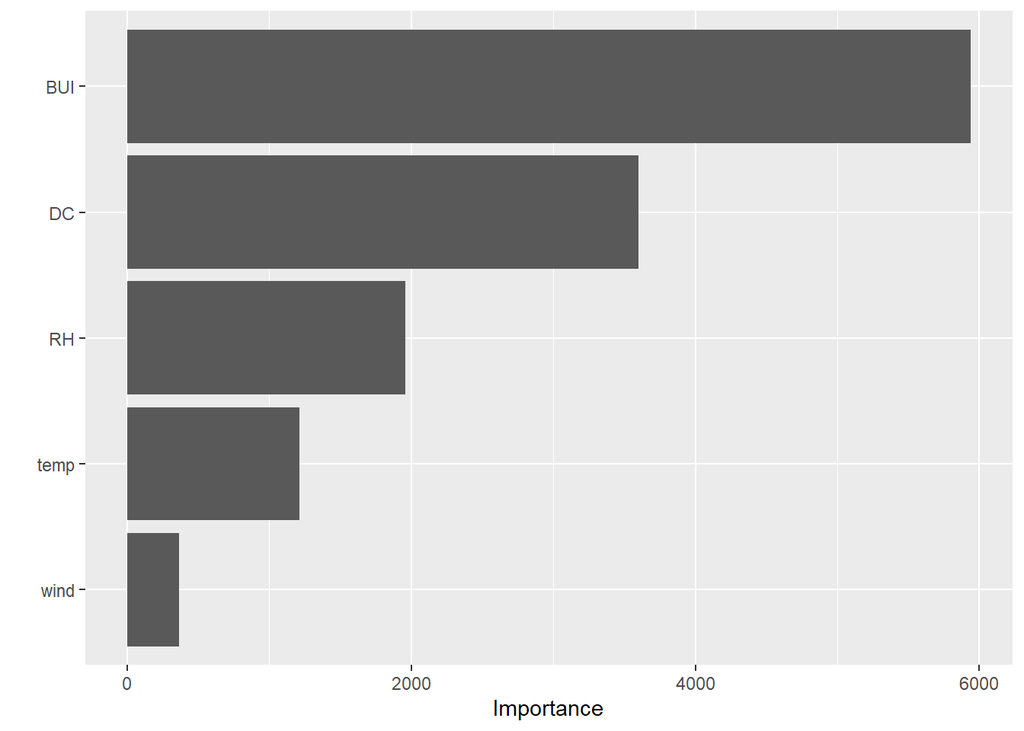

```r
set.seed(1234)

rf_imp_vip <- vip(model_rf_imp, num_features = 12)

plot(rf_imp_vip)
```

```r
set.seed(1234)

model_rf_perm <- ranger(
  FWI ~ .,
  data = firesAlg_6,
  importance='permutation'
)
print(model_rf_perm)
```

```
## Ranger result
##
## Call:
##  ranger(FWI ~ ., data = firesAlg_6, importance = "permutation")
##
## Type:                             Regression
## Number of trees:                  500
## Sample size:                      244
## Number of independent variables:  5
## Mtry:                             2
## Target node size:                 5
## Variable importance mode:         permutation
## Splitrule:                        variance
## OOB prediction error (MSE):       8.966676
## R squared (OOB):                  0.8375032
```

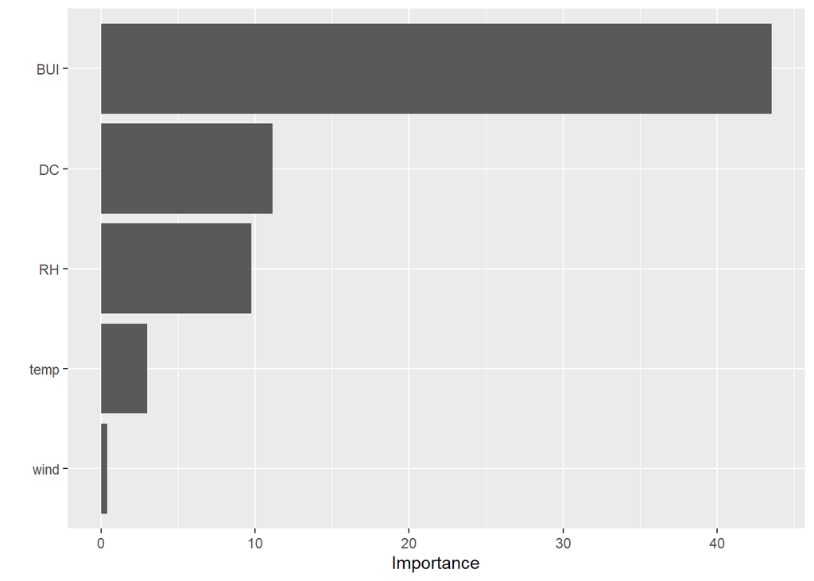

```r
rf_perm_vip <- vip(model_rf_perm, num_features = 15)

plot(rf_perm_vip)
```

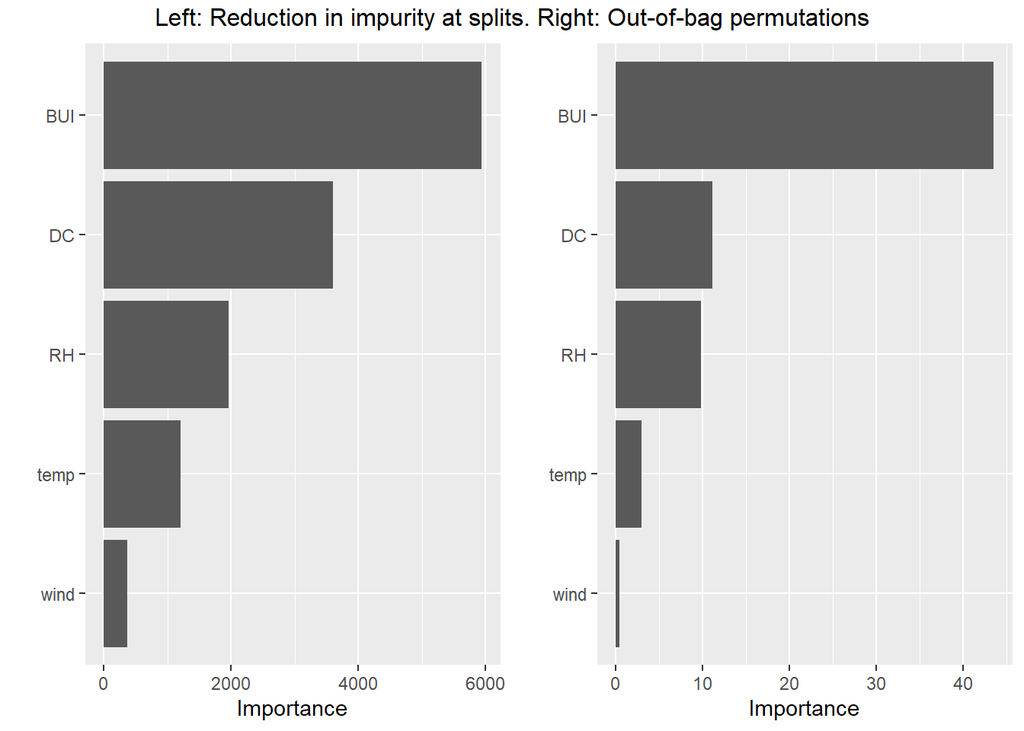

```r
rf_imp_vip <- vip(model_rf_imp, num_features = 12)
rf_perm_vip <- vip(model_rf_perm, num_features = 12)
grid.arrange(rf_imp_vip, rf_perm_vip, ncol=2, top="Left: Reduction in impurity at splits. Right: Out-of-bag permutations")
```

3. Compute the Variable Importance of each variable by Shapley Values. Plot the results and comment on them.

```r
# NO NEED TO DO THIS TECHER SAID
# rf_imp_vip <- vip(model_rf_imp, num_features = 12)
# rf_perm_vip <- vip(model_rf_perm, num_features = 12)
#
# rf_shapley <- vip(model_rf_imp, method="shap",
#                   pred_wrapper=yhat, num_features = 12,
#                   train = firesAlg_6, # argument 'train' must be provided
# )
#
# grid.arrange(rf_imp_vip, rf_perm_vip, rf_shapley,
#              ncol=2, nrow=2,
#              top="Top left: Impurity. Top right: oob permutations. Bottom left: Shapley values"
#             )
```

4. Use the DALEX library to do the Local (or Conditional) Dependence Plot for each explanatory variable.

```r
explainer_rf <- explain.default(model = model_rf_imp,
                               data = firesAlg_6,
                               y = firesAlg_6$FWI,
                               label = "Random Forest")
```

```
## Preparation of a new explainer is initiated
##   -> model label       :  Random Forest
##   -> data              :  244  rows  6  cols
##   -> target variable   :  244  values
##   -> predict function  :  yhat.ranger  will be used (  default  )
##   -> predicted values  :  No value for predict function target column. (  default  )
##   -> model_info        :  package ranger , ver. 0.16.0 , task regression (  default  )
##   -> predicted values  :  numerical, min =  0.01082905 , mean =  7.011408 , max =  27.96935
##   -> residual function :  difference between y and yhat (  default  )
##   -> residuals         :  numerical, min =  -4.644023 , mean =  0.0377723 , max =  4.270433
##   A new explainer has been created!
```

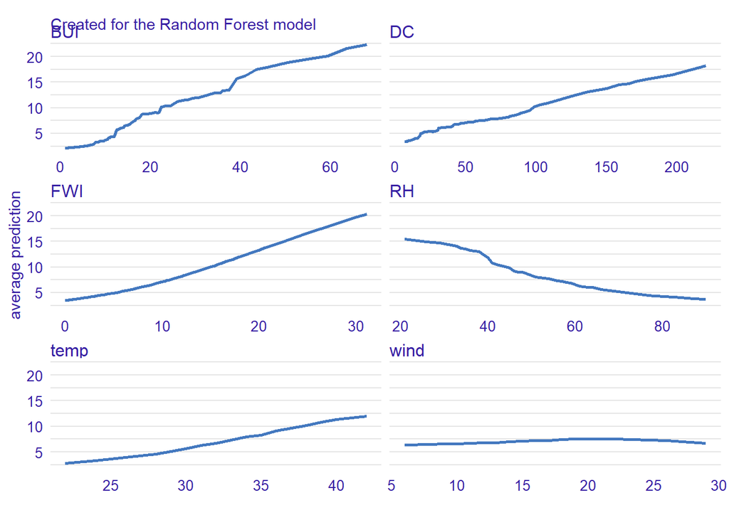

```r
CDP_rf <- model_profile(
  explainer=explainer_rf,
  variables = NULL,  # All variables are used
  N = NULL, # All available data are used
  groups = NULL,
  k = NULL,
  center = TRUE,
  type = "conditional" #  partial, conditional or accumulated
)

plot(CDP_rf, facet_ncol=2)
```

## 1.3 3. Your own Local (or Conditional) Dependence Plot

```r
x = firesAlg_6$BUI
y= firesAlg_6$FWI
```

```r
model_rf_imp <- ranger(
  BUI ~ .,
  data = firesAlg_6,
  importance='impurity' # default = none, no importances will be computed
)

sm.sp.1 <- smooth.spline(x = x, y = x,
                         cv = FALSE, all.knots = TRUE)
sm.sp.1
```

```
## Call:
## smooth.spline(x = x, y = x, cv = FALSE, all.knots = TRUE)
##
## Smoothing Parameter  spar= 1.376248  lambda= 0.1127038 (25 iterations)
## Equivalent Degrees of Freedom (Df): 3.175982
## Penalized Criterion (RSS): 2.314465e-15
## GCV: 9.737353e-18
```

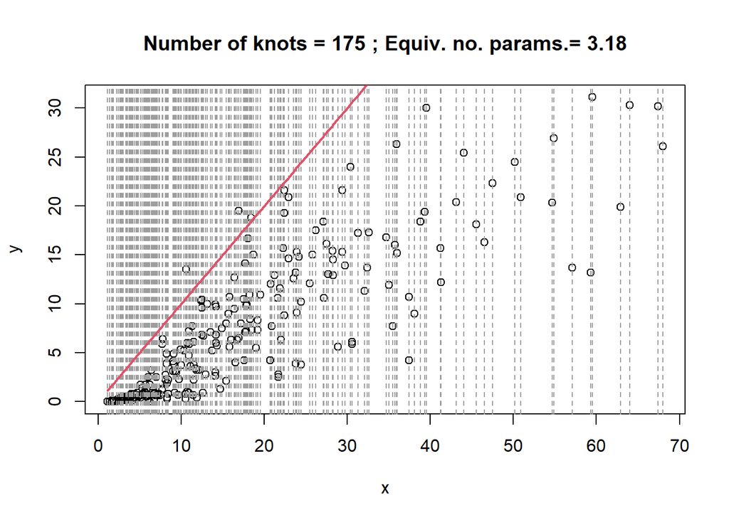

```r
plot(x = x, y = y,
     main=paste("Number of knots =",sm.sp.1$fit$nk,
                "; Equiv. no. params.=",round(sm.sp.1$df,2)))
abline(v=sm.sp.1$fit$min+sm.sp.1$fit$knot*sm.sp.1$fit$range, col=8, lty=2)
lines(sm.sp.1,col=2,lwd=2)
```

```r
explainer_rf <- explain.default(model = model_rf_imp,
                               data = firesAlg_6,
                               y = firesAlg_6$FWI,
                               label = "Random Forest")
```

```
## Preparation of a new explainer is initiated
##   -> model label       :  Random Forest
##   -> data              :  244  rows  6  cols
##   -> target variable   :  244  values
##   -> predict function  :  yhat.ranger  will be used (  default  )
##   -> predicted values  :  No value for predict function target column. (  default  )
##   -> model_info        :  package ranger , ver. 0.16.0 , task regression (  default  )
##   -> predicted values  :  numerical, min =  1.54262 , mean =  16.60808 , max =  61.84404
##   -> residual function :  difference between y and yhat (  default  )
##   -> residuals         :  numerical, min =  -39.97732 , mean =  -9.558897 , max =  1.334367
##   A new explainer has been created!
```

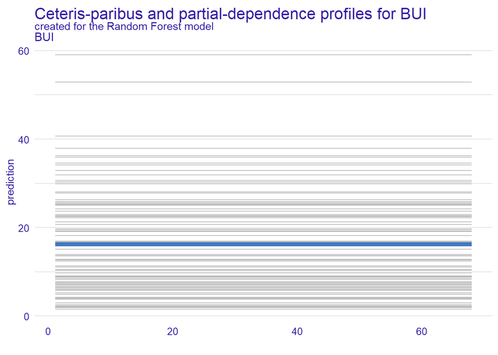

```r
mp_rf <- model_profile(explainer = explainer_rf,
  variables = "BUI",
  N = 100,
  type = "partial"
)

plot(mp_rf, geom = "profiles") +
  ggtitle("Ceteris-paribus and partial-dependence profiles for BUI")
```

```r
# grey = all individual expectation plots
# blue = average
```

## 1.4 4. Mixed Gaussian Model

Consider the dataset firesAlg_6. Do a model based clustering of these data assuming a Gaussian Mixture Model, allowing varying volume, shape, and orientation for different components in the mixture. Choose $k_{BIC}$, the best number of clusters $k\in\{2,\ldots,6\}$ according to BIC. Plot the resulting object from Mclust (do 4 different graphics: BIC, classification, uncertainty and density).

```r
library(mclust)
library(sm)
library(fpc)
```

```r
library(ggplot2)
library(cluster)
rng=2:6

GMM <- Mclust(as.matrix(firesAlg_6), parameters=TRUE, modelNames = "VVV")

clust.ind <- GMM$classification
summary(GMM,parameters=TRUE)
```

```
## ----------------------------------------------------
## Gaussian finite mixture model fitted by EM algorithm
## ----------------------------------------------------
##
## Mclust VVV (ellipsoidal, varying volume, shape, and orientation) model with 3
## components:
##
##  log-likelihood   n df       BIC       ICL
##       -4312.031 244 83 -9080.327 -9100.858
##
## Clustering table:
##   1   2   3
##  71 100  73
##
## Mixing probabilities:
##         1         2         3
## 0.2887009 0.4184614 0.2928377
##
## Means:
##            [,1]     [,2]      [,3]
## temp 29.6197154 34.20118 31.789008
## RH   70.0062577 53.47908 66.073196
## wind 15.8449219 15.73547 14.837466
## DC   10.2376845 86.56330 34.521125
## BUI   4.6663841 28.38034 11.781589
## FWI   0.4244967 12.79820  5.364995
##
## Variances:
## [,,1]
##             temp         RH      wind         DC         BUI        FWI
## temp  12.7435650 -21.630795 -5.980181   1.739702   3.9517619  0.6998742
## RH   -21.6307955 144.221136 17.492543 -14.866147 -18.5122566 -3.2766844
## wind  -5.9801809  17.492543 13.580515  -3.099119  -3.1407964 -0.2710930
## DC     1.7397023 -14.866147 -3.099119  19.720262   6.4468060  0.5094320
## BUI    3.9517619 -18.512257 -3.140796   6.446806   6.7431972  0.5550744
## FWI    0.6998742  -3.276684 -0.271093   0.509432   0.5550744  0.1002619
## [,,2]
##            temp         RH      wind          DC        BUI        FWI
## temp   8.695680 -21.115063 -2.396336    2.019011   3.834400   8.114320
## RH   -21.115063 198.860722  9.876687  227.227332  30.510184 -41.955567
## wind  -2.396336   9.876687  6.064014   14.310051   1.820451   0.755773
## DC     2.019011 227.227332 14.310051 2645.253639 657.950721 187.340891
## BUI    3.834400  30.510184  1.820451  657.950721 205.137410  76.077633
## FWI    8.114320 -41.955567  0.755773  187.340891  76.077633  56.936360
## [,,3]
##             temp         RH       wind         DC        BUI        FWI
## temp   7.4654879 -22.467921 -0.4077718   1.434625   4.696510   5.766754
## RH   -22.4679207 143.546769  5.0659344 -18.894534 -19.482285 -25.926469
## wind  -0.4077718   5.065934  4.1675021   8.259012   1.510754   0.800435
## DC     1.4346248 -18.894534  8.2590121 205.487368  61.147746  32.318481
## BUI    4.6965104 -19.482285  1.5107541  61.147746  24.215097  15.343166
## FWI    5.7667544 -25.926469  0.8004350  32.318481  15.343166  12.868855
```

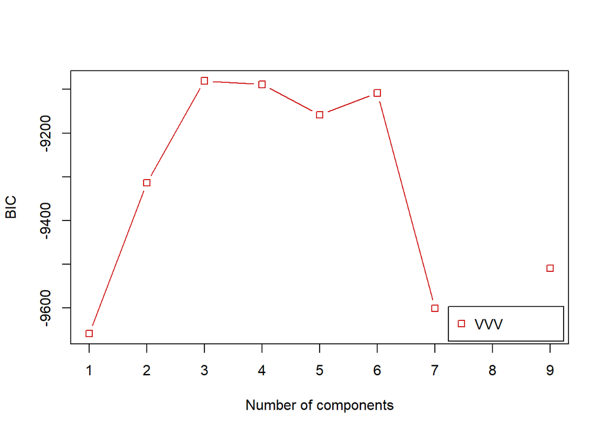

```r
plot(GMM, what="BIC",asp=1)
```

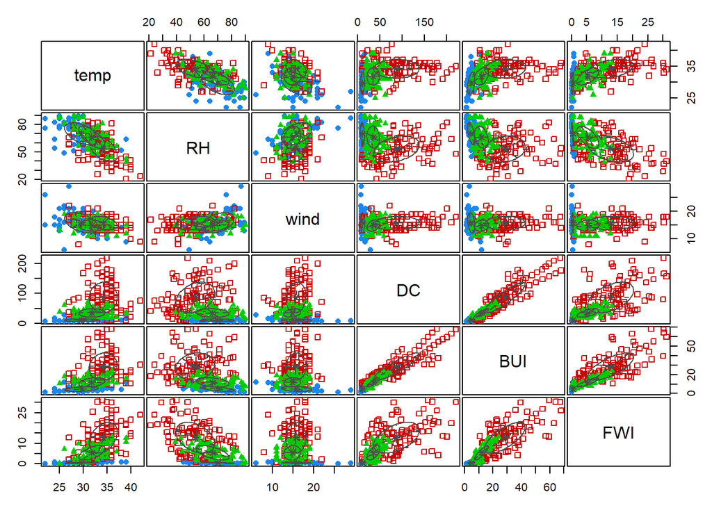

```r
plot(GMM, what="classification")
```

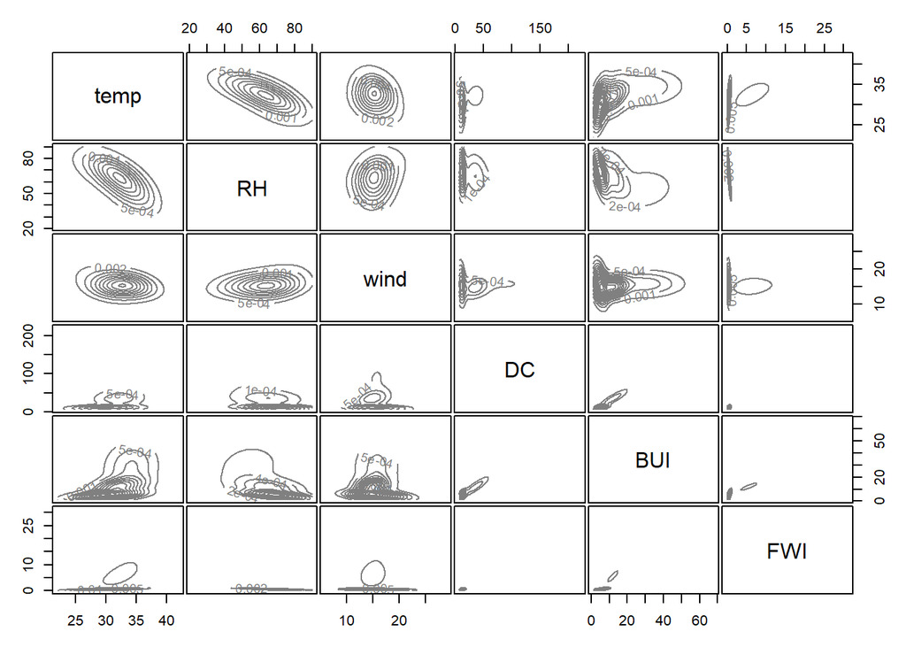

```r
plot(GMM, what="density")
```

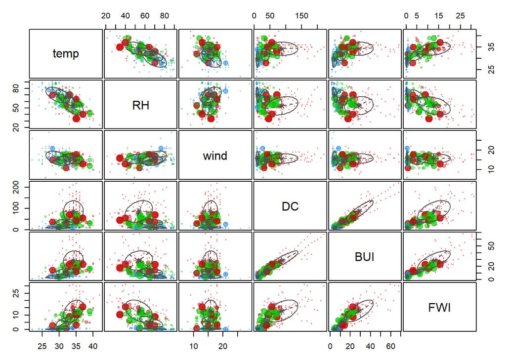

```r
plot(GMM, what="uncertainty")
```

## 1.5 5. DBCAN

Use DBSCAN to find clusters (and outliers) in the data set firesAlg_6, after centering and scaling the variables. Use $\varepsilon = 1$ and $\texttt{minPts}=8$. How many clusters have you obtained? How many outliers? Do a pairs plot of firesAlg_6 coloring the points according to the results of DBSCAN.

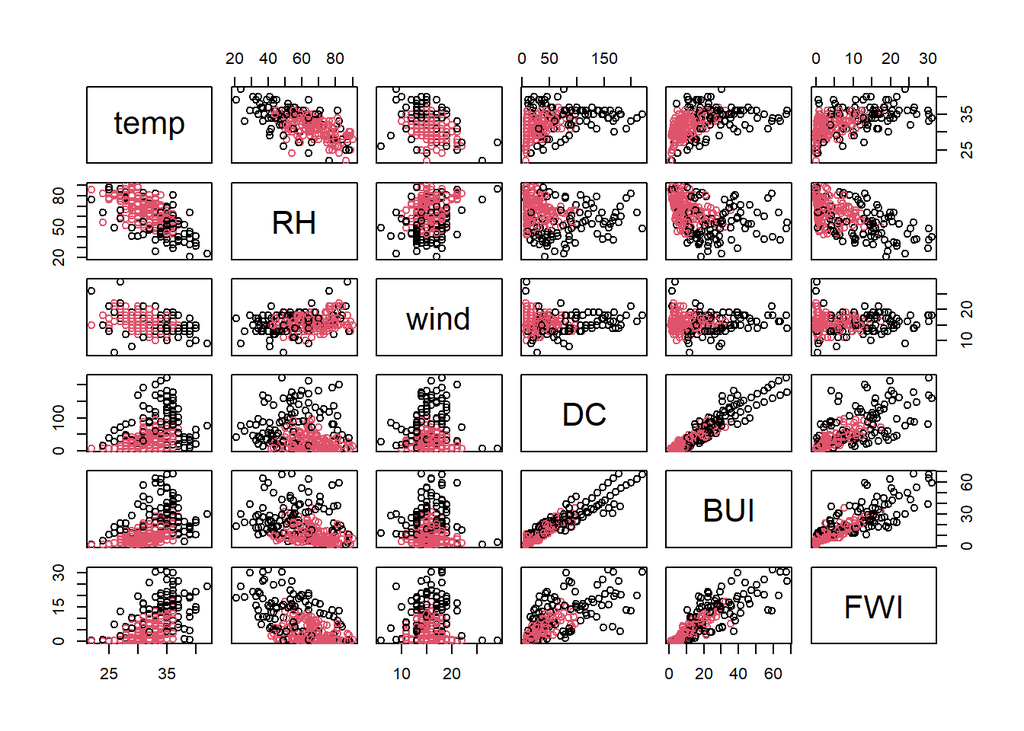

```r
library(fpc)

epsilon <- 1
minPts <- 8

X <- scale(firesAlg_6)


dbscan_result <- fpc::dbscan(X, eps = epsilon, MinPts = minPts, showplot = 0, scale = TRUE)

cluster_indices = dbscan_result$cluster
plot(firesAlg_6[,1:6], col=cluster_indices+1)
```

```r
dbscan_result
```

```
## dbscan Pts=244 MinPts=8 eps=1
##         0   1
## border 92  47
## seed    0 105
## total  92 152
```

```r
# 1 cluster has been detected
#table(dbscan_result$cluster)

# 92 outliers have been detected bz dbscan
(outliers = sum(dbscan_result$cluster==0))
```

```
## [1] 92
```

## 1.6 6. Nonlinear dimensionality reduction

Use a nonlinear dimensionality reduction method at your choice to obtain a 2-dimensional configuration for the data in firesAlg_6, after centering and scaling the variables.

Specify how you choose the required tuning parameters. Provide graphical representation of the output. In particular, show how the 6 original variables are related with the new 2 dimensions. Try to give an interpretation to the new 2 dimensions.

Using the local-continuity meta criteria for choosing the optimal tuning parameters.

```r
LCMC <- function(D1,D2,Kp=10){
  D1 <- as.matrix(D1)
  D2 <- as.matrix(D2)
  n <- dim(D1)[1]
  N.Kp.i <- numeric(n)
  for (i in 1:n){
    N1.i <- sort.int(D1[i,],index.return = TRUE)$ix[1:Kp]
    N2.i <- sort.int(D2[i,],index.return = TRUE)$ix[1:Kp]
    N.Kp.i[i] <- length(intersect(N1.i, N2.i))
  }
  N.Kp<-mean(N.Kp.i)
  M.Kp.adj <- N.Kp/Kp - Kp/(n-1)

  return(list(N.Kp.i=N.Kp.i, M.Kp.adj=M.Kp.adj))
}
```

### 1.6.1 t-SNE

```r
library("Rtsne")
```

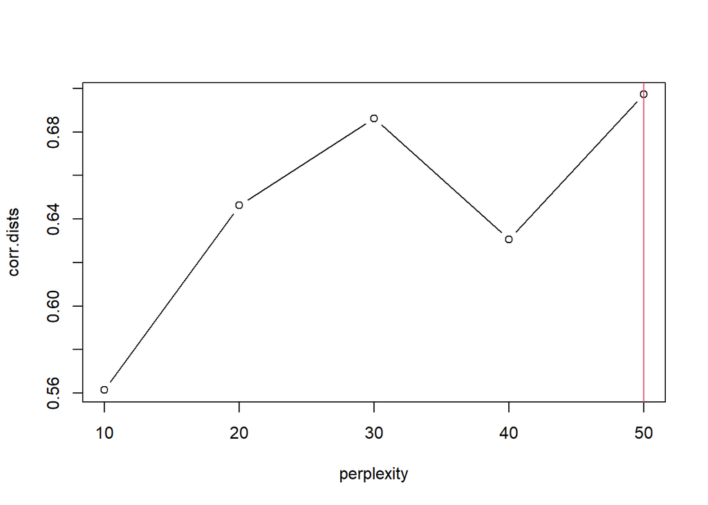

```r
D=dist(as.matrix(X))

set.seed(42)
theta= 0.0
perplexity <- seq(10,50,by=10)
q=2

corr.dists <- array(0,dim=length(perplexity))
tSNE.perp <- array(vector("list",1),dim=dim(corr.dists))

for (i in 1:length(perplexity)){
  tSNE.perp[[i]] <- Rtsne(D, dims=q,
                   perplexity=perplexity[i],
                   theta=theta, num_threads = 1)
    D2.perp <- dist(tSNE.perp[[i]]$Y)
    corr.dists[i] <- cor(D,D2.perp)^2
    #print(c(i,j,LC[i,j]))
}

i.max <- which.max(corr.dists)
perp.max <- perplexity[i.max]
tSNE.max <- tSNE.perp[[i.max]]
tSNE.corr.dists.max <- corr.dists[i.max]

plot(perplexity,corr.dists, type="b")
abline(v=perp.max, col=2)
```

```r
print(paste0("tSNE: perplexity.max=",perp.max,", corr.dists(perplexity.max)=",corr.dists[i.max]))
```

```
## [1] "tSNE: perplexity.max=50, corr.dists(perplexity.max)=0.697192158624335"
```

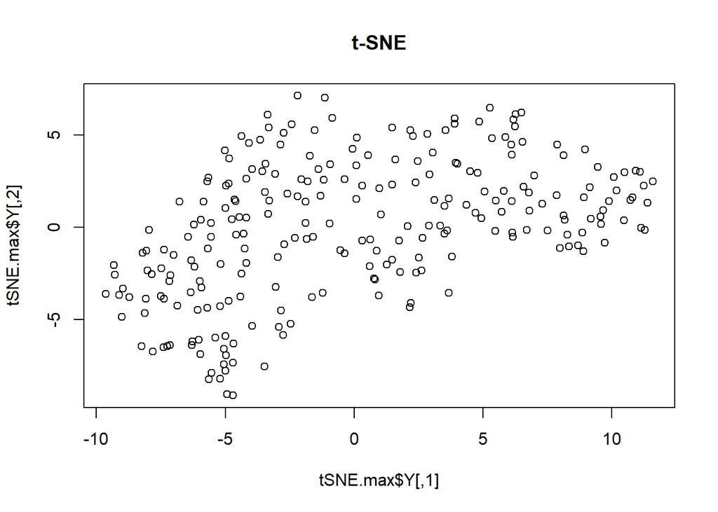

```r
plot(tSNE.max$Y, main="t-SNE")
```

Interpretation: The points in the new 2-dim configuration bz t-SNE is not very dense and seems well spreaded. Lower values can be found on the left side, while there is a slight positive linear increase to the right side. This linear correlation can be found in some important vriables like BUI, FWI, DC and temp.

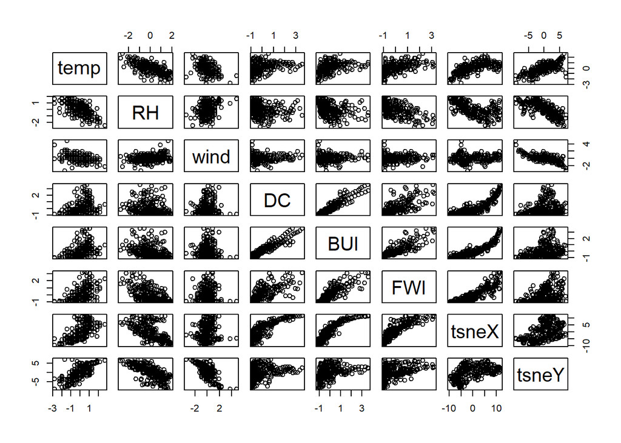

```r
aux <- cbind(X, tsneX=tSNE.max$Y[,1], tsneY=tSNE.max$Y[,2])
pairs(aux)
```

### 1.6.2 ISOMAP

```r
# library(vegan)
#
# x=dist(as.matrix(firesAlg_6))
# q<-2
# k <- 5
#
# ismp <- isomap(x,ndim=q, k=k)
# plot(ismp,n.col=3,main="Output of ISOMAP Algorithm")
# text(ismp$points[,1],ismp$points[,2],rownames(data),pos=3, cex=.5)
```

Choosing tuning parameter k with local continuity meta critera between 5-100.

```r
library(vegan)
```

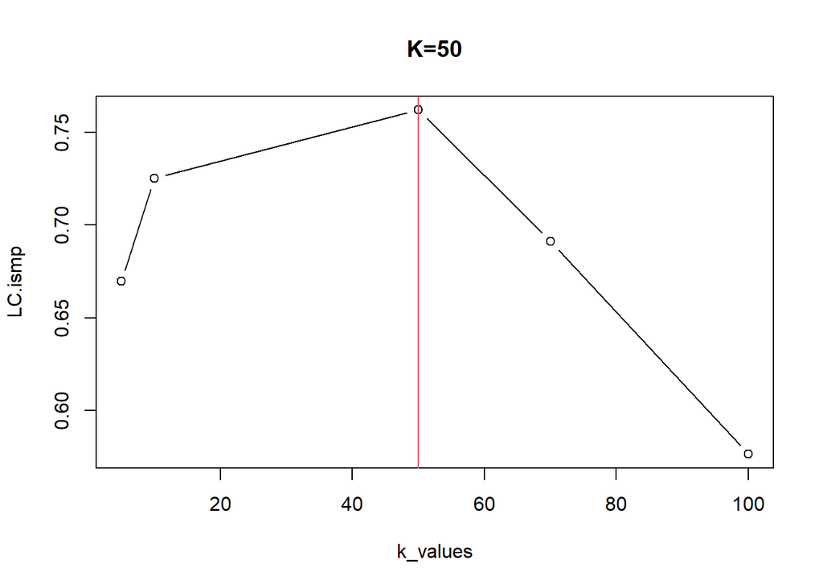

```r
k_values <- c(5, 10, 50, 70, 100)
q=2
D1 <- dist(firesAlg_6)
LC.ismp <- numeric(length(k_values))

isomap_results <- vector("list",length(k_values))

for (i in 1:length(k_values)){
   k <- k_values[i]
   isomap_results[[i]] <- isomap(D1, ndim=q, k=k)
   dist_k <- dist(isomap_results[[i]]$points[,1:q])
   LC.ismp[i] <- LCMC(D1, dist_k, k)$M.Kp.adj
}

i_max <- which.max(LC.ismp)
k_max <- k_values[i_max]
isomap_max <- isomap_results[i_max]

plot(k_values, LC.ismp, type="b", main=paste0("K=",round(k_max,4)))
abline(v=k_max,col=2)
```

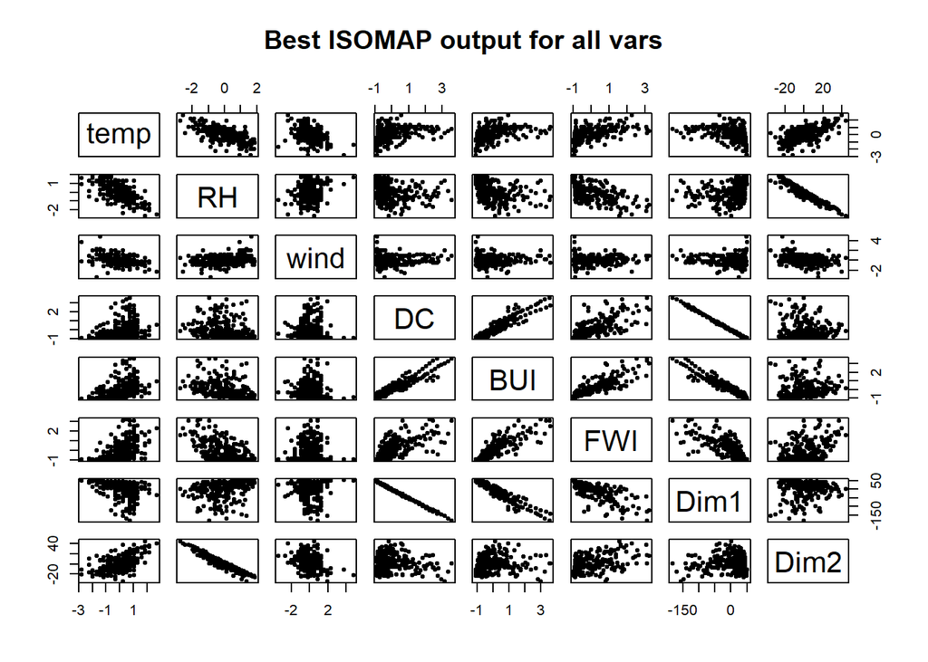

```r
best_k_isomap <- isomap(D1, ndim=q,  k=k_max)
pairs(cbind(X ,isomap=best_k_isomap$points[,1:2]), pch=20, main="Best ISOMAP output for all vars")
```

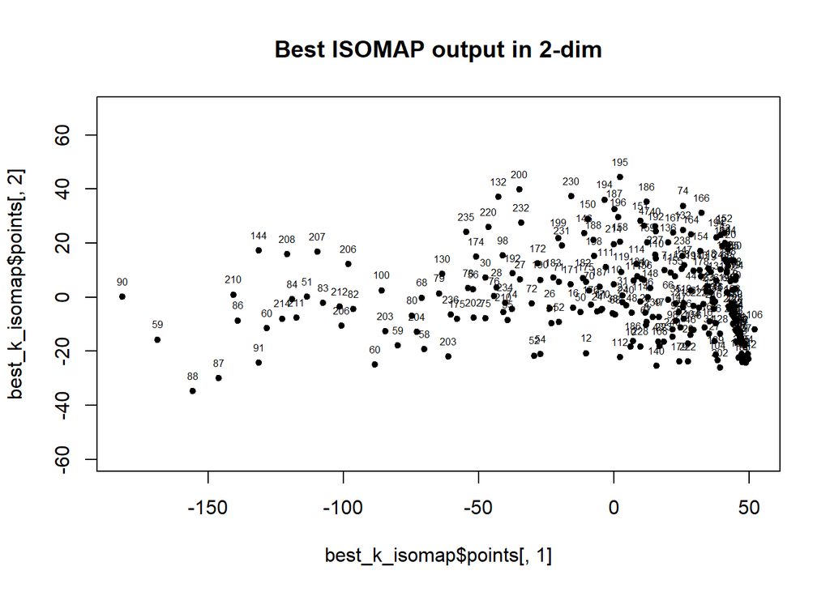

```r
plot(best_k_isomap$points[,1], best_k_isomap$points[,2], pch=20, main="Best ISOMAP output in 2-dim", as=1)
text(best_k_isomap$points[,1], best_k_isomap$points[,2], rownames(data),pos=3, cex=.5)
```

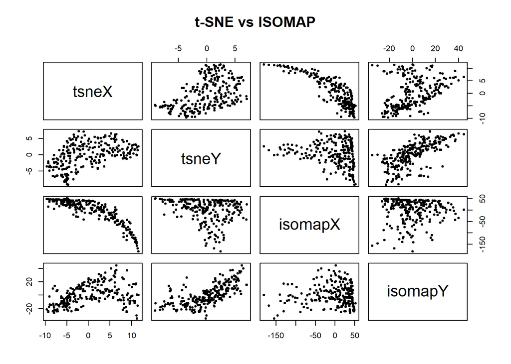

```r
pairs(cbind(tsneX=tSNE.max$Y[,1], tsneY=tSNE.max$Y[,2],isomapX=best_k_isomap$points[,1], isomapY=best_k_isomap$points[,2]), pch=20, main="t-SNE vs ISOMAP")
```